# Praca Domowa 3

Mikołaj Garstecki, Julia Girtler

2023-03-28

## **Cel pracy i przebieg badania**

Celem Pracy domowowej była obserwacja, jak prezentacja danych wpływa na ich odbiór. Stworzyliśmy dwie niezależne ankiety, każda z nich została przeprowadzona na odzielnej próbce badawczej. Na pytania odpowiedziały łącznie 42 osoby, natomiast w każdej podgrupie było 21 respondentów. Eksperyment został w dużej mierze oparty na eksperymencie z lat osiemdziesiątych http://euclid.psych.yorku.ca/www/psy6135/papers/ClevelandMcGill1984.pdf

## **Eksperyment Pierwszy**

### Opis Eksperymetnu

Zestawiony został wykres kołowy z wykresem słupkowym. Ankietowani mieli za zadanie oszacować jaką wartosć procentową zajmują poszczególne części, kolejno:B C D. Podana została również informacja, że wartości sumują się do 100%.

Przykładowe sformułowanie pytania: “*Wykres przedstawia 4 słupki, które sumują się do 100%. Jaką wartość przyjmuje słupek B twoim zdaniem?*”

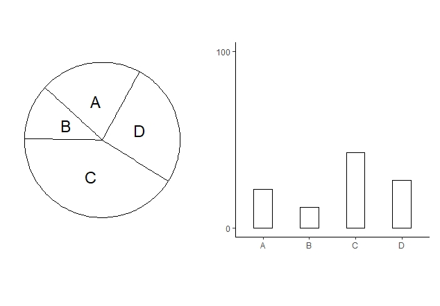

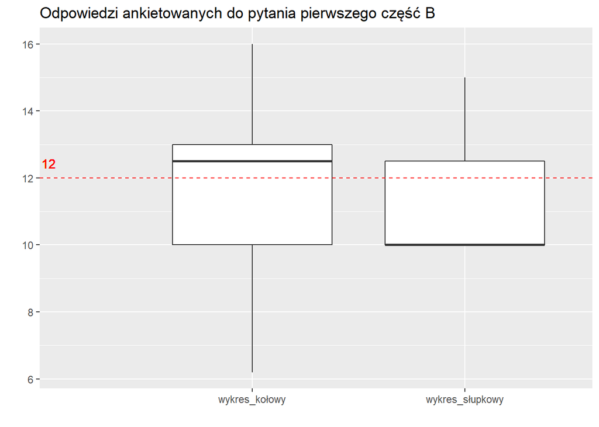

```r
obsw1
```

```
##  wykres_kolowyB  wykres_slupkowyB
##  Min.   : 6.20   Min.   :10.00
##  1st Qu.:10.00   1st Qu.:10.00
##  Median :12.50   Median :10.00
##  Mean   :12.18   Mean   :11.21
##  3rd Qu.:13.00   3rd Qu.:12.50
##  Max.   :16.00   Max.   :15.00
```

```r
odchylenie_standardowe_kolowyB
```

```
## [1] 2.315579
```

```r
odchylenie_standardowe_slupkowyB
```

```
## [1] 2.052873
```

### Obserwacje

Poprawna odpowiedź została zaznaczona czerwoną linią. Kolejno wynosi ona: 12%, 43%, 27%.

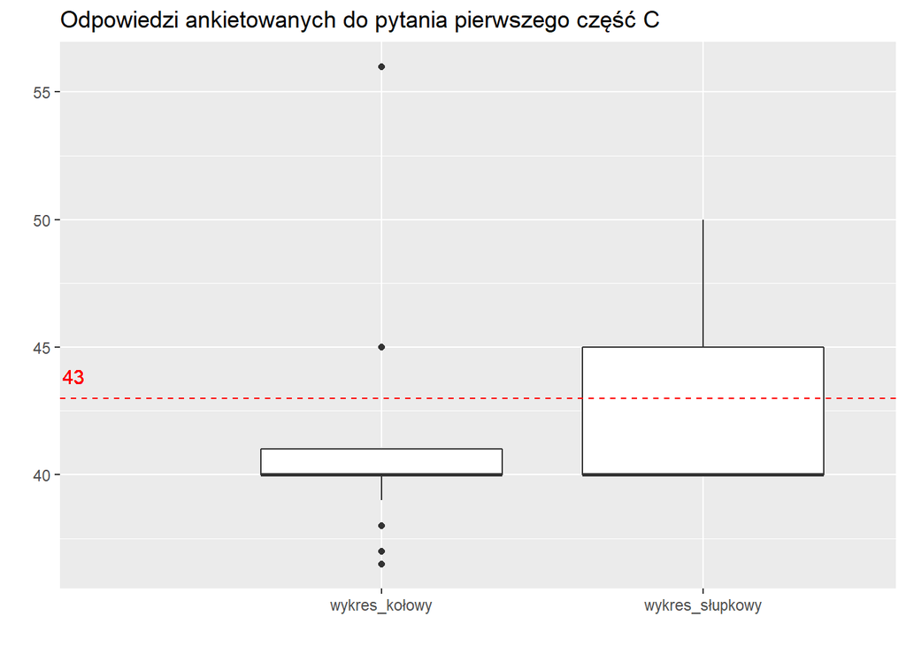

```r
obsw2
```

```
##  wykres_kolowyC  wykres_slupkowyC
##  Min.   :36.50   Min.   :40.00
##  1st Qu.:40.00   1st Qu.:40.00
##  Median :40.00   Median :40.00
##  Mean   :41.31   Mean   :41.98
##  3rd Qu.:41.00   3rd Qu.:45.00
##  Max.   :56.00   Max.   :50.00
```

```r
odchylenie_standardowe_kolowyC
```

```
## [1] 4.166762
```

```r
odchylenie_standardowe_slupkowyC
```

```
## [1] 3.317455
```

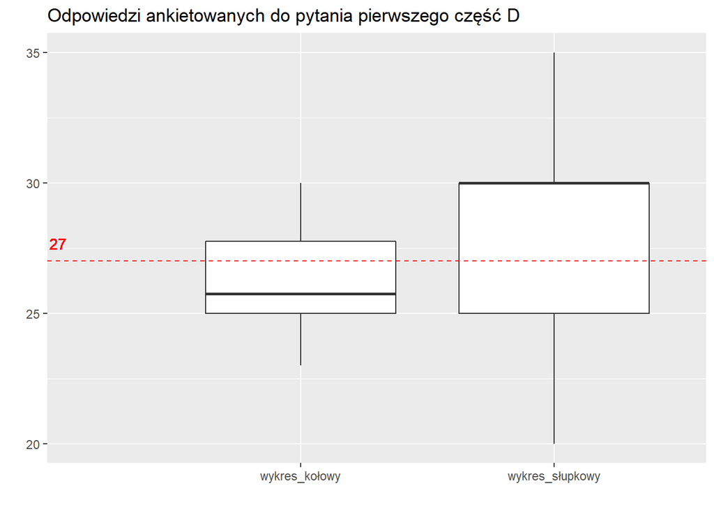

```r
obsw3
```

```
##  wykres_kolowyD  wykres_slupkowyD
##  Min.   :23.00   Min.   :20.00
##  1st Qu.:25.00   1st Qu.:25.00
##  Median :25.75   Median :30.00
##  Mean   :26.48   Mean   :27.86
##  3rd Qu.:27.75   3rd Qu.:30.00
##  Max.   :30.00   Max.   :35.00
```

```r
odchylenie_standardowe_kolowyD
```

```
## [1] 2.095785
```

```r
odchylenie_standardowe_slupkowyD
```

```
## [1] 3.356521
```

### Wnioski

- Średnia była bliższa poprawnej odpowiedzi w części C dla wykresu słupkowego, w części B, D dla wykresu kołowego
- Odchylenie standardowe było większe dla wykreu kołowego w części B i C, natomiast w części D dla wykresu słupkowego

  Wyniki okazały się dla nas zaskakujące gdyż w 2 na 3 przypadki podgrupa z wykresem kołowym poradziła sobie lepiej. Wiemy jednak, że problem ten jest tylko pozorny gdyż do wykresu słupkowego o wiele łatwiej jest dopasować skalę wartości na osi y w porównaniu do wykresu kołowego. Ciekawym byłoby również poszerzenie badania o dodanie skali do obydwu wykresów i sprawdzenie jak ankietowani poradziliby sobie z interpretacją danych.

  Ważnym spostrzeżeniem jest również fakt, że średnie w obydwu przypadkach były bardzo bliskie wartości prawdziwej, pomimo tego, że ludzie zazwyczaj przypisywali wartości zaokrąglone.

## **Drugi eksperyment**

### Opis eksperymentu

Zestawiony został wykres słupkowy dzielony z wykresem słupkowym. Dane do wykresów zostały wygenerowane losowo z przedziału (0,1). Ankietowani mieli za zadanie oszacować jaką część (procentowo) większego słupka stanowi słupek mniejszy. W każdej podgrupie osoby miały jedno zadanie na wykresie słupkowym i jedno na wykresie słupkowym dzielonym dla dwóch różnych zbiorów danych.

Część 1

Przykładowe pytanie zadane ankietowanym brzmiało następująco:

“Dwie kolumny zostały podzielone na mniejsze części. Na każdej z tych kolumn zaznaczono kropką jedną część. Określ jaki procent większej części zajmuje mniejsza. Wynik podaj w procentach.  
Przykład:Jedna część wynosi 15 a druga 5wtedy mniejsza część zajmuje **33%** większej”

Wykresy zaprezentowane w ankiecie w części pierwszej wyglądały następująco:

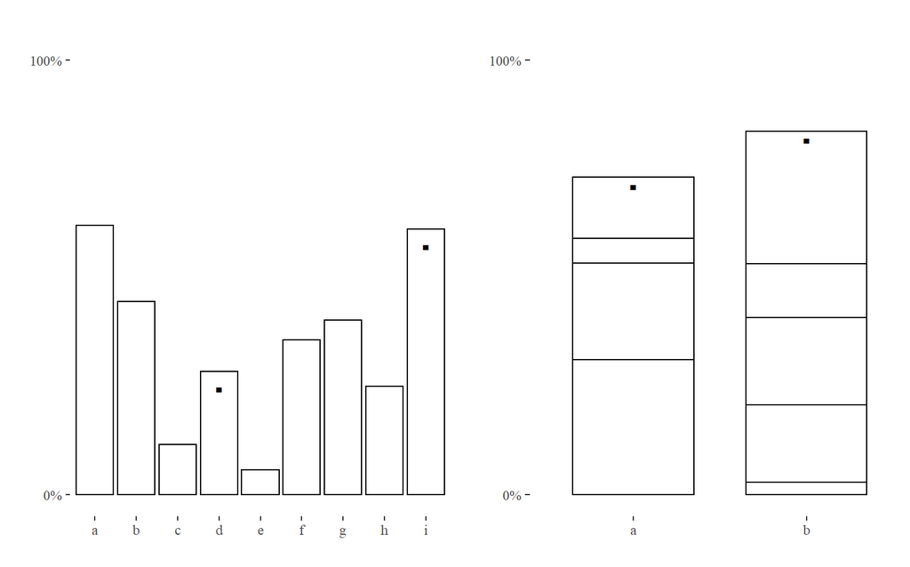

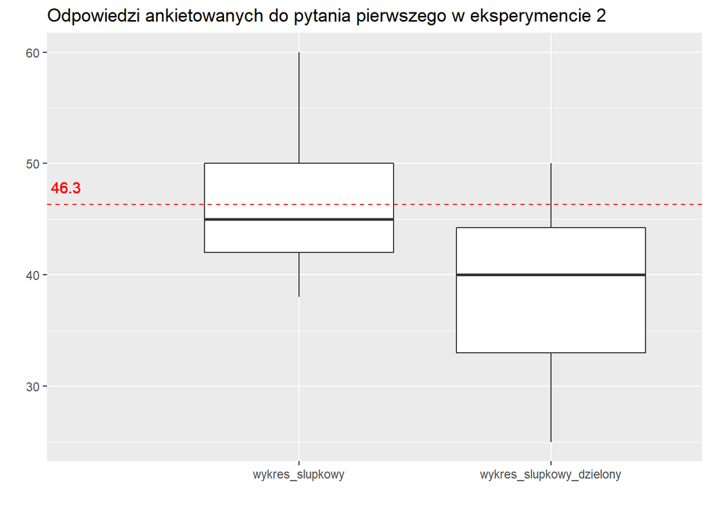

```r
obsw4
```

```
##  wykres_slupkowy1 wykres_slupkowy_dzielony1
##  Min.   :38.00    Min.   :25.00
##  1st Qu.:42.00    1st Qu.:33.00
##  Median :45.00    Median :40.00
##  Mean   :46.41    Mean   :38.79
##  3rd Qu.:50.00    3rd Qu.:44.25
##  Max.   :60.00    Max.   :50.00
```

```r
odchylenie_standardowe_slupkowy1
```

```
## [1] 2.810386
```

```r
odchylenie_standardowe_slupkowy_dzielony1
```

```
## [1] 3.033453
```

Część 2

Wykresy zaprezentowane w ankiecie w części drugiej wyglądały następująco:

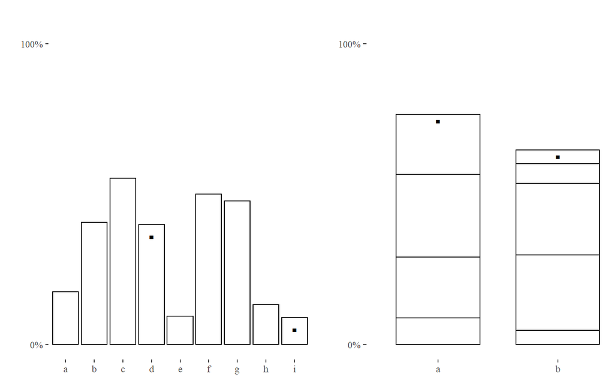

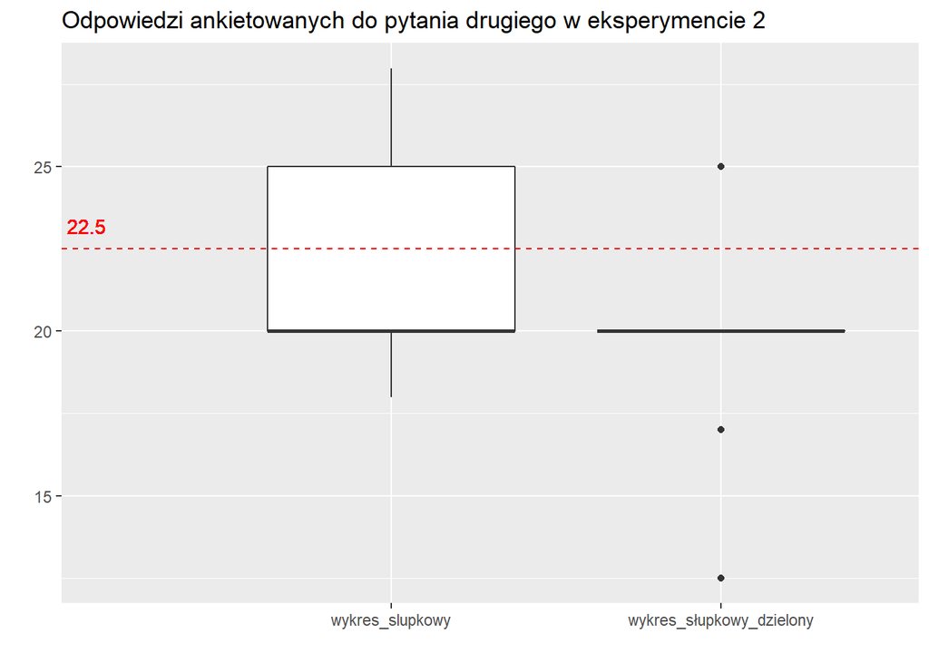

### Obserwacje

Poprawna odpowiedź została zaznaczona czerwoną linią. Kolejno wynosi ona: 46,3%, 22,5%.

```r
obsw5
```

```
##  wykres_slupkowy2 wykres_slupkowy_dzielony2
##  Min.   :18.00    Min.   :12.50
##  1st Qu.:20.00    1st Qu.:20.00
##  Median :20.00    Median :20.00
##  Mean   :21.77    Mean   :20.52
##  3rd Qu.:25.00    3rd Qu.:20.00
##  Max.   :28.00    Max.   :25.00
```

```r
odchylenie_standardowe_slupkowy2
```

```
## [1] 5.456836
```

```r
odchylenie_standardowe_slupkowy_dzielony2
```

```
## [1] 6.719273
```

### Wnioski

- Średnia była bliższa poprawnej odpowiedzi w obu zadaniach dla wykresu słupkowego
- Odchylenie standardowe było mniejsze dla wykresu słupkowego w obu zadaniach
- Odpowiedzi ankietowanych w przypadku wykresu słupkowego dzielonego były zaniżane
- we wszystkich zadaniach ankietowani podawali odpowiedź bliższą poprawnej, gdy mieli do czynienia z wykresem słupkowym

## **Podsumowanie**

Eksperymenty przeprowadzone powyżej pozwoliły zauważyć różnice pomiędzy wykresem słupkowym, kołowym oraz słupkowym dzielonym. Co ciekawe w kontrze do tez z wykładu ludzie lepiej oszacowali wartości na wykresie kołowym co jednak było w dużej mierze spowodowane brakiem skali na obydwu grafikach. W przypadkudodania skali do wykresów uważamy, że rezultat badania byłby zdecydowanie inny. Interesujący jest fakt, że przy wykresie kołowym ludzie chętniej szacowali wykres za pomocą ułamków wpisując takie odpowiedzi jak 12% czy 33% co jest zbliżone do wartości odpowiednio jedna ósma oraz jedna trzecia. W przypadku wykresu słupkowego częściej odpowiadano w sposób dziesiętny to znaczy 10%,20%,30%,40%..

W eksperymencie drugim można zauważyć zdecydowaną przewagę wykresu słupkowego nad wykresem słupkowym dzielonym. Zarówno odchylenie standardowe mówiące w pewnym sensie o pewności ludzi i stałości oszacowania co do obstawionej odpowiedzi. Również to w wykresie słupkowym była lepsza predykcja wyników.